# CSCI E-63C Week 7 midterm exam

# Introduction

The goal of midterm is to apply some of the methods for supervised and unsupervised analysis to a new dataset. We will work with data characterizing the relationship between wine quality and its analytical characteristics [available at UCI ML repository](https://archive.ics.uci.edu/ml/datasets/Wine+Quality) as well as in this course website on canvas. The overall goal will be to use data modeling approaches to understand which wine properties influence the most wine quality as determined by expert evaluation. The output variable in this case assigns wine to discrete categories between 0 (the worst) and 10 (the best), so that this problem can be formulated as classification or regression – here we will stick to the latter and treat/model outcome as continuous variable. For more details please see [dataset description available at UCI ML](https://archive.ics.uci.edu/ml/machine-learning-databases/wine-quality/winequality.names) or corresponding file in this course website on canvas. Please note that there is another, much smaller, dataset on UCI ML also characterizing wine in terms of its analytical properties – make sure to use correct URL as shown above, or, to eliminate possibility for ambiguity, the data available on the course website in canvas – the correct dataset contains several thousand observations. For simplicity, clarity and to decrease your dependency on the network reliability and UCI ML availability you are advised to download data made available in this course website to your local folder and work with this local copy.

There are two compilations of data available under the URL shown above as well as in the course website in canvas – separate for red and for white wine – please develop models of wine quality for each of them, investigate attributes deemed important for wine quality in both and determine whether quality of red and white wine is influenced predominantly by the same or different analytical properties (i.e. predictors in these datasets). Lastly, as an exercise in unsupervised learning you will be asked to combine analytical data for red and white wine and describe the structure of the resulting data – whether there are any well defined clusters, what subsets of observations they appear to represent, which attributes seem to affect the most this structure in the data, etc.

Finally, as you will notice, the instructions here are terser than in the previous homework assignments. We expect that you use what you’ve learned in the class to complete the analysis and draw appropriate conclusions based on the data. All approaches that you are expected to apply here have been exercised in the preceeding weekly assignments – please feel free to consult your submissions and/or official solutions as to how they have applied to different datasets. As always, if something appears to be unclear, please ask questions – we may change to private mode those that in our opinion reveal too many details as we see fit.

# Sub-problem 1: load and summarize the data (20 points)

Download and read in the data, produce numerical and graphical summaries of the dataset attributes, decide whether they can be used for modeling in untransformed form or any transformations are justified, comment on correlation structure and whether some of the predictors suggest relationship with the outcome.

> read in the data

```r
wine_columns = c('fixed_acidity','volatile_acidity','citric_acid','residual_sugar','chlorides','free_sulfur_dioxide', 'total_sulfur_dioxide', 'density','pH', 'sulphates', 'alcohol', 'y_quality')

red = read.table('./data/winequality-red.csv', sep=';', header=TRUE, as.is=TRUE, quote='', col.names=wine_columns)

white = read.table('./data/winequality-white.csv', sep=';', header=TRUE, as.is=TRUE, quote='', col.names=wine_columns)
```

> produce numerical (summaries)

Call `summary` on red to get some summary statistics on the red wines:

```r
summary(red)
```

```
##  fixed_acidity   volatile_acidity  citric_acid    residual_sugar
##  Min.   : 4.60   Min.   :0.1200   Min.   :0.000   Min.   : 0.900
##  1st Qu.: 7.10   1st Qu.:0.3900   1st Qu.:0.090   1st Qu.: 1.900
##  Median : 7.90   Median :0.5200   Median :0.260   Median : 2.200
##  Mean   : 8.32   Mean   :0.5278   Mean   :0.271   Mean   : 2.539
##  3rd Qu.: 9.20   3rd Qu.:0.6400   3rd Qu.:0.420   3rd Qu.: 2.600
##  Max.   :15.90   Max.   :1.5800   Max.   :1.000   Max.   :15.500
##    chlorides       free_sulfur_dioxide total_sulfur_dioxide
##  Min.   :0.01200   Min.   : 1.00       Min.   :  6.00
##  1st Qu.:0.07000   1st Qu.: 7.00       1st Qu.: 22.00
##  Median :0.07900   Median :14.00       Median : 38.00
##  Mean   :0.08747   Mean   :15.87       Mean   : 46.47
##  3rd Qu.:0.09000   3rd Qu.:21.00       3rd Qu.: 62.00
##  Max.   :0.61100   Max.   :72.00       Max.   :289.00
##     density             pH          sulphates         alcohol
##  Min.   :0.9901   Min.   :2.740   Min.   :0.3300   Min.   : 8.40
##  1st Qu.:0.9956   1st Qu.:3.210   1st Qu.:0.5500   1st Qu.: 9.50
##  Median :0.9968   Median :3.310   Median :0.6200   Median :10.20
##  Mean   :0.9967   Mean   :3.311   Mean   :0.6581   Mean   :10.42
##  3rd Qu.:0.9978   3rd Qu.:3.400   3rd Qu.:0.7300   3rd Qu.:11.10
##  Max.   :1.0037   Max.   :4.010   Max.   :2.0000   Max.   :14.90
##    y_quality
##  Min.   :3.000
##  1st Qu.:5.000
##  Median :6.000
##  Mean   :5.636
##  3rd Qu.:6.000
##  Max.   :8.000
```

And then on the white wines dataset:

```r
summary(white)
```

```
##  fixed_acidity    volatile_acidity  citric_acid     residual_sugar
##  Min.   : 3.800   Min.   :0.0800   Min.   :0.0000   Min.   : 0.600
##  1st Qu.: 6.300   1st Qu.:0.2100   1st Qu.:0.2700   1st Qu.: 1.700
##  Median : 6.800   Median :0.2600   Median :0.3200   Median : 5.200
##  Mean   : 6.855   Mean   :0.2782   Mean   :0.3342   Mean   : 6.391
##  3rd Qu.: 7.300   3rd Qu.:0.3200   3rd Qu.:0.3900   3rd Qu.: 9.900
##  Max.   :14.200   Max.   :1.1000   Max.   :1.6600   Max.   :65.800
##    chlorides       free_sulfur_dioxide total_sulfur_dioxide
##  Min.   :0.00900   Min.   :  2.00      Min.   :  9.0
##  1st Qu.:0.03600   1st Qu.: 23.00      1st Qu.:108.0
##  Median :0.04300   Median : 34.00      Median :134.0
##  Mean   :0.04577   Mean   : 35.31      Mean   :138.4
##  3rd Qu.:0.05000   3rd Qu.: 46.00      3rd Qu.:167.0
##  Max.   :0.34600   Max.   :289.00      Max.   :440.0
##     density             pH          sulphates         alcohol
##  Min.   :0.9871   Min.   :2.720   Min.   :0.2200   Min.   : 8.00
##  1st Qu.:0.9917   1st Qu.:3.090   1st Qu.:0.4100   1st Qu.: 9.50
##  Median :0.9937   Median :3.180   Median :0.4700   Median :10.40
##  Mean   :0.9940   Mean   :3.188   Mean   :0.4898   Mean   :10.51
##  3rd Qu.:0.9961   3rd Qu.:3.280   3rd Qu.:0.5500   3rd Qu.:11.40
##  Max.   :1.0390   Max.   :3.820   Max.   :1.0800   Max.   :14.20
##    y_quality
##  Min.   :3.000
##  1st Qu.:5.000
##  Median :6.000
##  Mean   :5.878
##  3rd Qu.:6.000
##  Max.   :9.000
```

`str` on both to confirm datatypes and see dimensions of each dataset:

```r
str(red)
```

```
## 'data.frame':    1599 obs. of  12 variables:
##  $ fixed_acidity       : num  7.4 7.8 7.8 11.2 7.4 7.4 7.9 7.3 7.8 7.5 ...
##  $ volatile_acidity    : num  0.7 0.88 0.76 0.28 0.7 0.66 0.6 0.65 0.58 0.5 ...
##  $ citric_acid         : num  0 0 0.04 0.56 0 0 0.06 0 0.02 0.36 ...
##  $ residual_sugar      : num  1.9 2.6 2.3 1.9 1.9 1.8 1.6 1.2 2 6.1 ...
##  $ chlorides           : num  0.076 0.098 0.092 0.075 0.076 0.075 0.069 0.065 0.073 0.071 ...
##  $ free_sulfur_dioxide : num  11 25 15 17 11 13 15 15 9 17 ...
##  $ total_sulfur_dioxide: num  34 67 54 60 34 40 59 21 18 102 ...
##  $ density             : num  0.998 0.997 0.997 0.998 0.998 ...
##  $ pH                  : num  3.51 3.2 3.26 3.16 3.51 3.51 3.3 3.39 3.36 3.35 ...
##  $ sulphates           : num  0.56 0.68 0.65 0.58 0.56 0.56 0.46 0.47 0.57 0.8 ...
##  $ alcohol             : num  9.4 9.8 9.8 9.8 9.4 9.4 9.4 10 9.5 10.5 ...
##  $ y_quality           : int  5 5 5 6 5 5 5 7 7 5 ...
```

```r
str(white)
```

```
## 'data.frame':    4898 obs. of  12 variables:
##  $ fixed_acidity       : num  7 6.3 8.1 7.2 7.2 8.1 6.2 7 6.3 8.1 ...
##  $ volatile_acidity    : num  0.27 0.3 0.28 0.23 0.23 0.28 0.32 0.27 0.3 0.22 ...
##  $ citric_acid         : num  0.36 0.34 0.4 0.32 0.32 0.4 0.16 0.36 0.34 0.43 ...
##  $ residual_sugar      : num  20.7 1.6 6.9 8.5 8.5 6.9 7 20.7 1.6 1.5 ...
##  $ chlorides           : num  0.045 0.049 0.05 0.058 0.058 0.05 0.045 0.045 0.049 0.044 ...
##  $ free_sulfur_dioxide : num  45 14 30 47 47 30 30 45 14 28 ...
##  $ total_sulfur_dioxide: num  170 132 97 186 186 97 136 170 132 129 ...
##  $ density             : num  1.001 0.994 0.995 0.996 0.996 ...
##  $ pH                  : num  3 3.3 3.26 3.19 3.19 3.26 3.18 3 3.3 3.22 ...
##  $ sulphates           : num  0.45 0.49 0.44 0.4 0.4 0.44 0.47 0.45 0.49 0.45 ...
##  $ alcohol             : num  8.8 9.5 10.1 9.9 9.9 10.1 9.6 8.8 9.5 11 ...
##  $ y_quality           : int  6 6 6 6 6 6 6 6 6 6 ...
```

> and graphical summaries of the dataset attributes

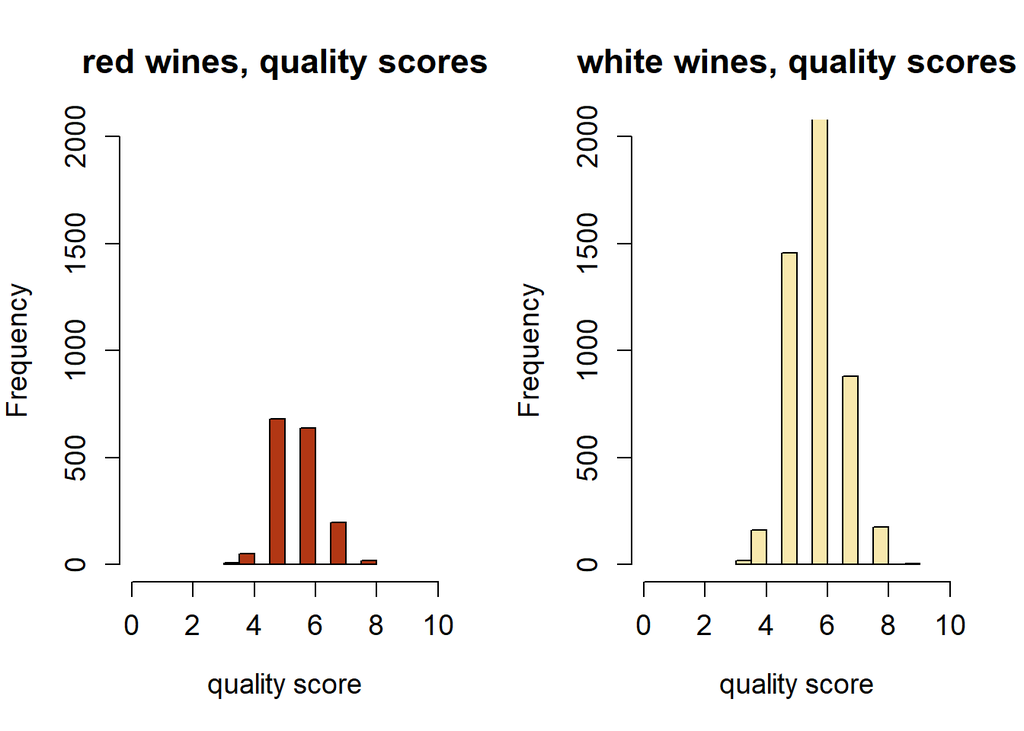

```r
oldPar <- par(mfrow=c(1:2), ps=14)
x_range = c(0,10)
y_range = c(1,2000)
red_col ='#B23714'
white_col ='#F8E8AD'
hist(red$y_quality, main='red wines, quality scores', col=red_col, xlim=x_range, xlab='quality score', ylim=y_range)
hist(white$y_quality, main='white wines, quality scores', col=white_col, xlim=x_range, xlab='quality score', ylim=y_range)
```

Dataset description states the quality scores range from 0 to 10 and that there are more “ordinary” wines than excellent or poor ones, histogram confirms. Plot them on the same scale to emphasize the disparity in size of datasets, don’t think much information is lost by reducing the bar sizes on the red wines.

### red wine boxplots

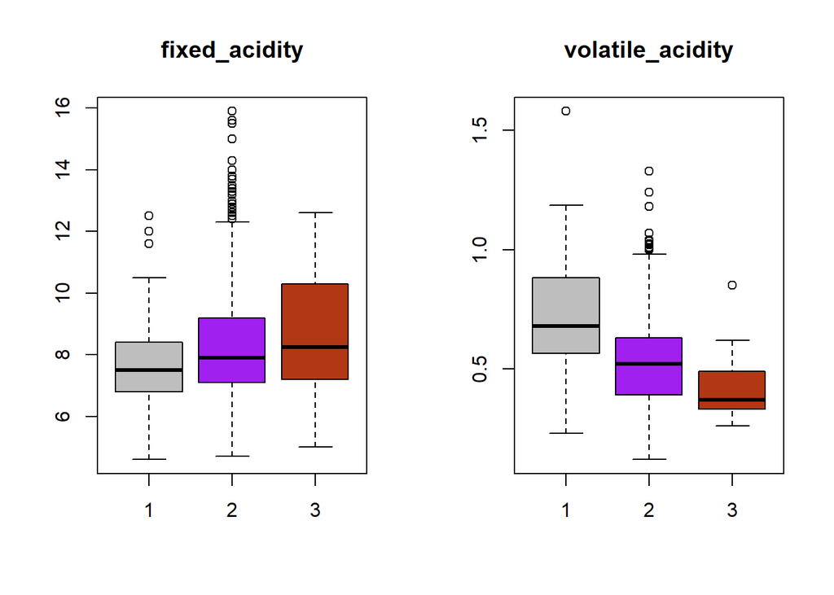

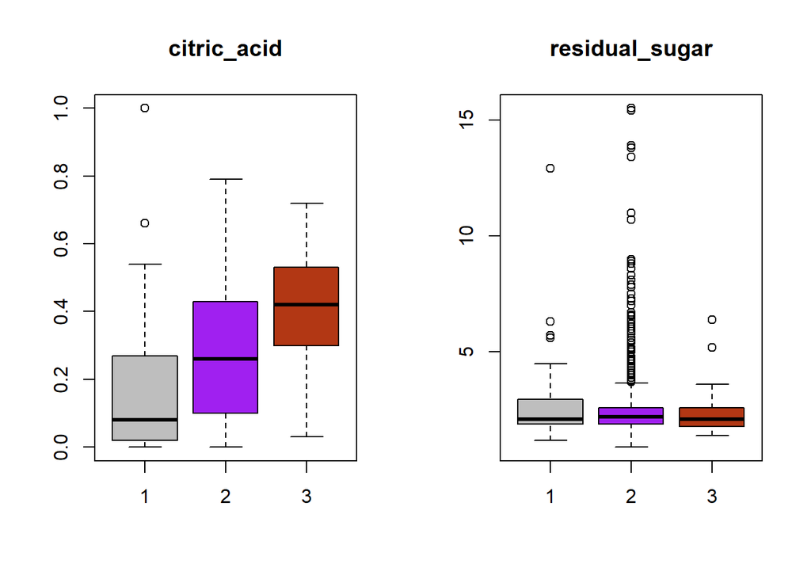

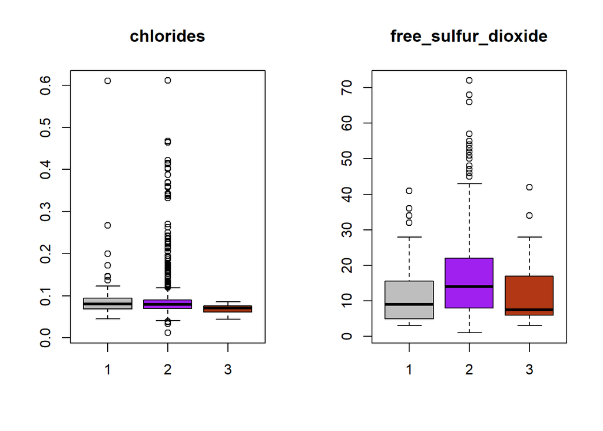

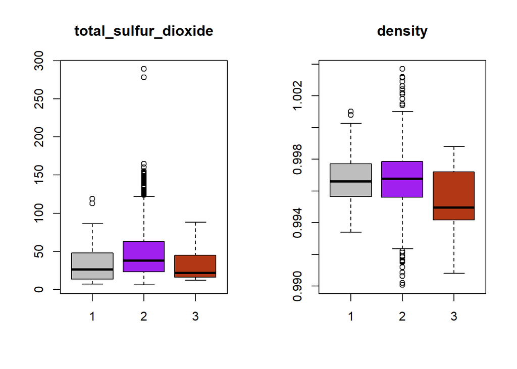

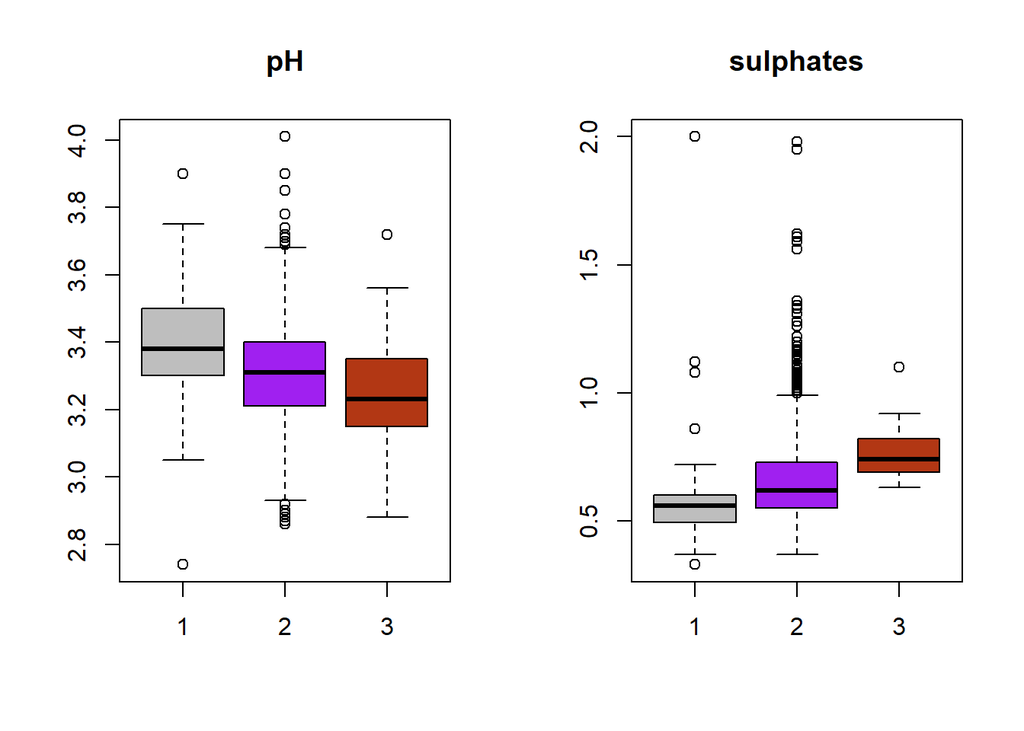

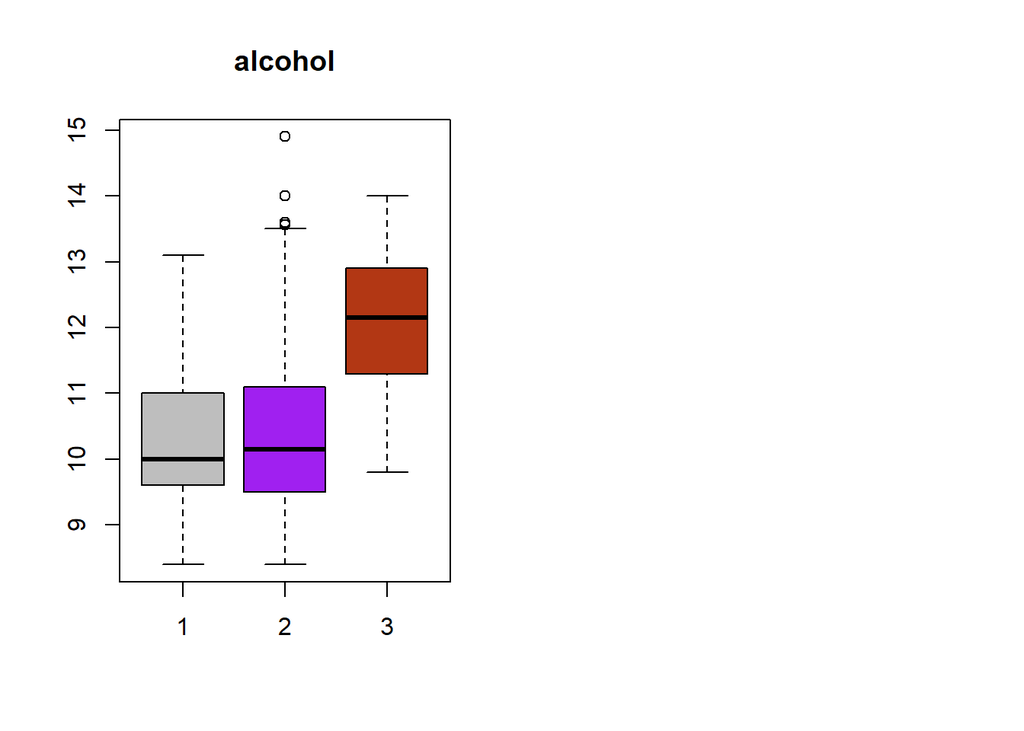

```r
# after looking at the distribution of quality scores, decide 5/6/7 represent "ordinary" wines = 2
# anything below that is a 1 and the better ones, > 7, get a 3
wine_binner = function(x){ifelse(x<5, 1, ifelse(x<8, 2, 3))}
red_quality_bins = sapply(red$y_quality, wine_binner)

oldpar=par(mfrow=c(1,2))
for ( i in 1:11 ) {
  boxplot(red[[i]] ~ red_quality_bins,
  col=c('gray','purple',red_col),
  main=names(red)[i])
}
```

Above are some box plots for each of the predictor variables against `quality`, where the `y_quality` values have somewhat arbitrarily been divided into three bins:  
* poor for scores < 5, in gray  
* ordinary for scores of 5/6/7, purple  
* excellent for scores > 7, maroon

These red wine boxplots imply a few relationships:  
* higher values for `fixed_acidity`, `citric_acid`, `sulphates`, and most distinctly, `alcohol`, are associated with higher quality wines. `alcohol` aside, lower values for those same variables correspond with lower wine `y_quality` scores.  
* An inverse relationship to the above, lower values ~ high quality, is displayed for `volatile_acidity`, `density`, and `pH`.  
* The variables `residual_sugar`, `chlorides`, `free_sulfur_dioxide`, and `total_sulfur_dioxide` appear to be independent of `y_quality` scores.

Looking at some of the stronger correlations, to improve a glass of red wine maybe add lemon juice to increase `citric_acid`/decrease `pH` levels, then drop in a shot of vodka to increase `alcohol` levels. (Ha ha, I’m not a wine drinker, guessing that won’t work so well.)

### on to white wine boxplots

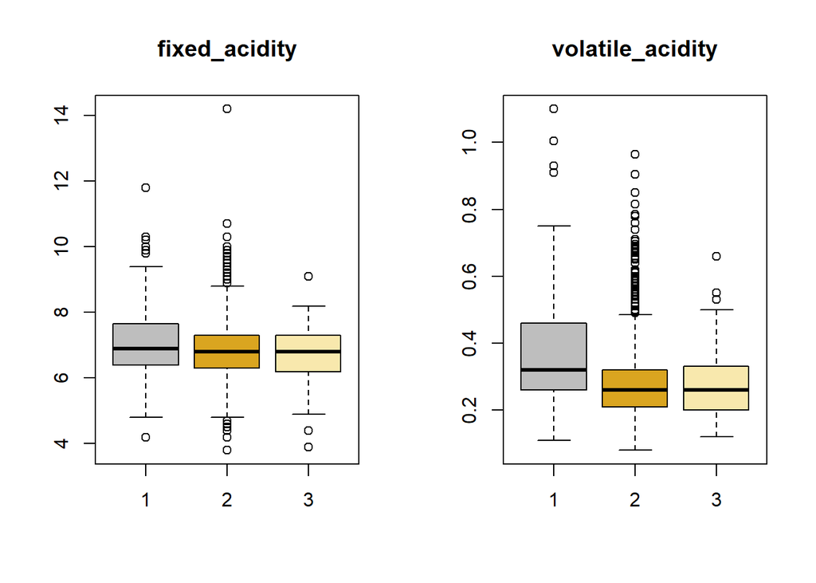

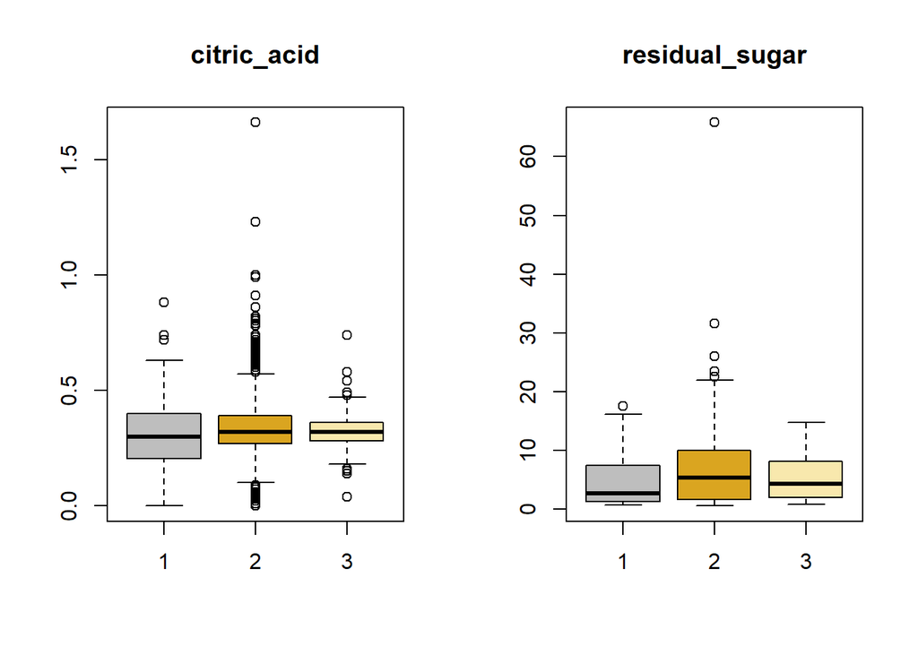

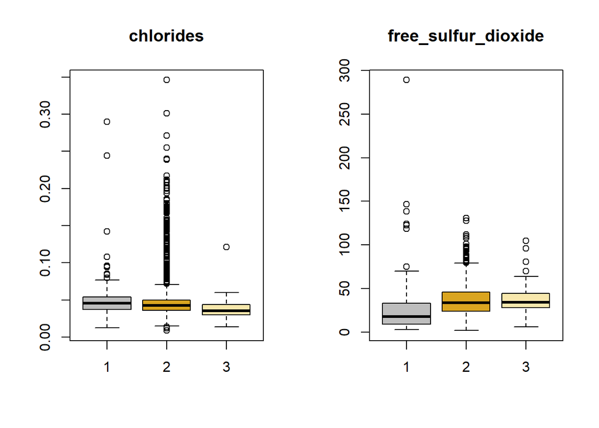

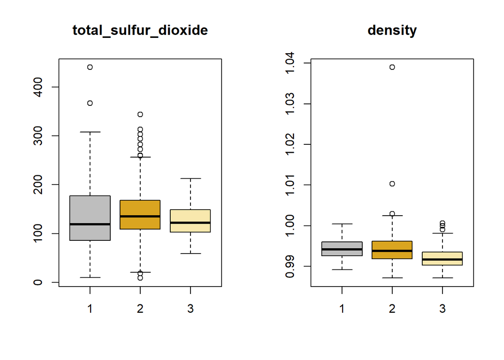

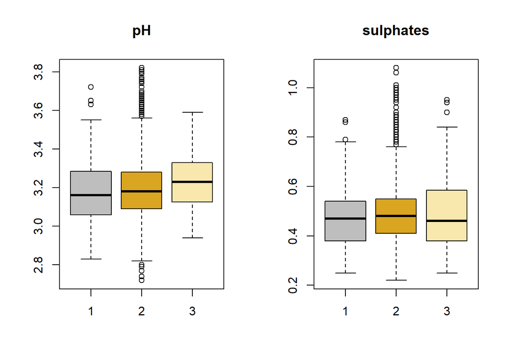

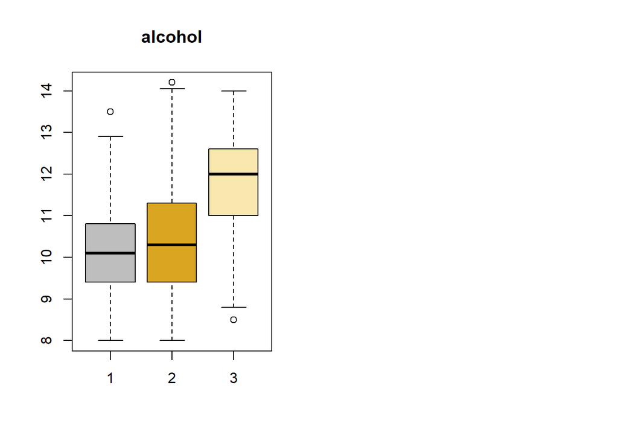

```r
white_quality_bins = sapply(white$y_quality, wine_binner)

oldpar=par(mfrow=c(1,2))
for ( i in 1:11 ) {
  boxplot(white[[i]] ~ white_quality_bins,
  col=c('gray','goldenrod',white_col),
  main=names(white)[i])
}
```

The story for white wines changes a bit:  
* the previous relationships for `fixed_acidity`, `citric_acid`, `pH`, and `sulphates` are no longer apparent  
* the negative correlation between `volatile_acidity` and quality is still there, but to a lesser degree  
* there now appears to be weak correspondence involving `free_sulfur_dioxide`, increased levels resulting in higher quality (or at least less-poor quality) wine  
* correlations for remaining variables appear mostly unchanged. Notably, the relationship between higher `alcohol` levels leading to higher quality wine scores remains just as pronounced as with red wine.

> decide whether they (dataset attributes) can be used for modeling in untransformed form or any transformations are justified

For the first step in evaluating the source data sets I’m going to look at `red` and:  
1. create a multiple linear regression model on the 11 predictor variables vs. `y_quality` based on different “versions” of the data  
2. create diagnostic plots of the above models

For `1.` above, the models will be based on:  
1. data as supplied  
2. data with all values log-transformed  
3. data with all predictor variables log-transformed, leaving `y_quality` in its original state

### raw red data

```r
lm_red_raw = lm(y_quality~., red)
summary(lm_red_raw)
```

```
##
## Call:
## lm(formula = y_quality ~ ., data = red)
##
## Residuals:
##      Min       1Q   Median       3Q      Max
## -2.68911 -0.36652 -0.04699  0.45202  2.02498
##
## Coefficients:
##                         Estimate  Std. Error t value Pr(>|t|)
## (Intercept)           21.9652084  21.1945750   1.036   0.3002
## fixed_acidity          0.0249906   0.0259485   0.963   0.3357
## volatile_acidity      -1.0835903   0.1211013  -8.948  < 2e-16 ***
## citric_acid           -0.1825639   0.1471762  -1.240   0.2150
## residual_sugar         0.0163313   0.0150021   1.089   0.2765
## chlorides             -1.8742252   0.4192832  -4.470 8.37e-06 ***
## free_sulfur_dioxide    0.0043613   0.0021713   2.009   0.0447 *
## total_sulfur_dioxide  -0.0032646   0.0007287  -4.480 8.00e-06 ***
## density              -17.8811638  21.6330999  -0.827   0.4086
## pH                    -0.4136531   0.1915974  -2.159   0.0310 *
## sulphates              0.9163344   0.1143375   8.014 2.13e-15 ***
## alcohol                0.2761977   0.0264836  10.429  < 2e-16 ***
## ---
## Signif. codes:  0 '***' 0.001 '**' 0.01 '*' 0.05 '.' 0.1 ' ' 1
##
## Residual standard error: 0.648 on 1587 degrees of freedom
## Multiple R-squared:  0.3606, Adjusted R-squared:  0.3561
## F-statistic: 81.35 on 11 and 1587 DF,  p-value: < 2.2e-16
```

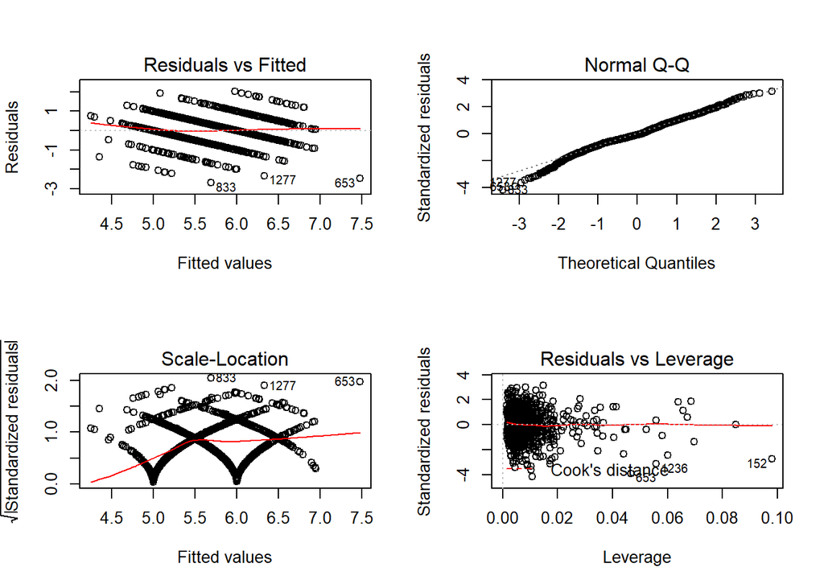

```r
oldpar=par(mfrow=c(2,2))
plot(lm_red_raw)
```

### red, all variables log-transformed

```r
# log transform all columns
red_loggy_all = log(red+1)
lm_red_loggy_all = lm(y_quality~., red_loggy_all)
summary(lm_red_loggy_all)
```

```
##
## Call:
## lm(formula = y_quality ~ ., data = red_loggy_all)
##
## Residuals:
##      Min       1Q   Median       3Q      Max
## -0.51177 -0.05083 -0.00499  0.06926  0.27889
##
## Coefficients:
##                       Estimate Std. Error t value  Pr(>|t|)
## (Intercept)           5.327371   4.749294   1.122   0.26215
## fixed_acidity         0.058952   0.039964   1.475   0.14038
## volatile_acidity     -0.274983   0.029618  -9.284   < 2e-16 ***
## citric_acid          -0.063666   0.028694  -2.219   0.02664 *
## residual_sugar        0.010098   0.012707   0.795   0.42694
## chlorides            -0.315844   0.076437  -4.132 0.0000378 ***
## free_sulfur_dioxide   0.016154   0.006785   2.381   0.01738 *
## total_sulfur_dioxide -0.020126   0.006523  -3.085   0.00207 **
## density              -6.251071   7.025402  -0.890   0.37372
## pH                   -0.228828   0.131154  -1.745   0.08123 .
## sulphates             0.267088   0.032067   8.329   < 2e-16 ***
## alcohol               0.462217   0.049030   9.427   < 2e-16 ***
## ---
## Signif. codes:  0 '***' 0.001 '**' 0.01 '*' 0.05 '.' 0.1 ' ' 1
##
## Residual standard error: 0.09955 on 1587 degrees of freedom
## Multiple R-squared:  0.3468, Adjusted R-squared:  0.3423
## F-statistic: 76.61 on 11 and 1587 DF,  p-value: < 2.2e-16
```

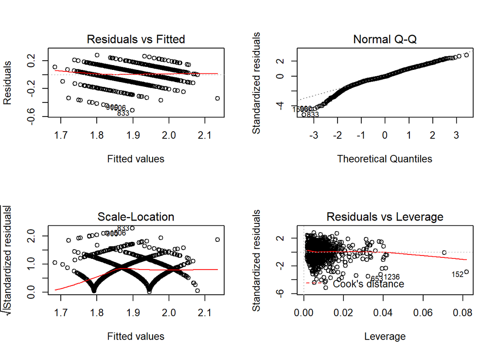

```r
oldpar=par(mfrow=c(2,2))
plot(lm_red_loggy_all)
```

### red, predictors log-transformed

```r
# log transform all the predictor columns
red_loggy_preds = cbind(log(red[,-12]+1), red[,12])
colnames(red_loggy_preds) = wine_columns
lm_red_loggy_preds = lm(y_quality~., red_loggy_preds)
summary(lm_red_loggy_preds)
```

```
##
## Call:
## lm(formula = y_quality ~ ., data = red_loggy_preds)
##
## Residuals:
##      Min       1Q   Median       3Q      Max
## -2.72505 -0.35954 -0.05451  0.44487  2.02204
##
## Coefficients:
##                       Estimate Std. Error t value  Pr(>|t|)
## (Intercept)           44.23472   30.85785   1.433  0.151912
## fixed_acidity          0.49661    0.25966   1.913  0.055988 .
## volatile_acidity      -1.69552    0.19244  -8.811   < 2e-16 ***
## citric_acid           -0.36357    0.18644  -1.950  0.051339 .
## residual_sugar         0.10591    0.08256   1.283  0.199774
## chlorides             -2.07534    0.49664  -4.179 0.0000309 ***
## free_sulfur_dioxide    0.10575    0.04408   2.399  0.016553 *
## total_sulfur_dioxide  -0.14856    0.04238  -3.505  0.000469 ***
## density              -65.37829   45.64653  -1.432  0.152263
## pH                    -1.18035    0.85216  -1.385  0.166207
## sulphates              1.83586    0.20835   8.811   < 2e-16 ***
## alcohol                3.04745    0.31857   9.566   < 2e-16 ***
## ---
## Signif. codes:  0 '***' 0.001 '**' 0.01 '*' 0.05 '.' 0.1 ' ' 1
##
## Residual standard error: 0.6468 on 1587 degrees of freedom
## Multiple R-squared:  0.3629, Adjusted R-squared:  0.3585
## F-statistic: 82.19 on 11 and 1587 DF,  p-value: < 2.2e-16
```

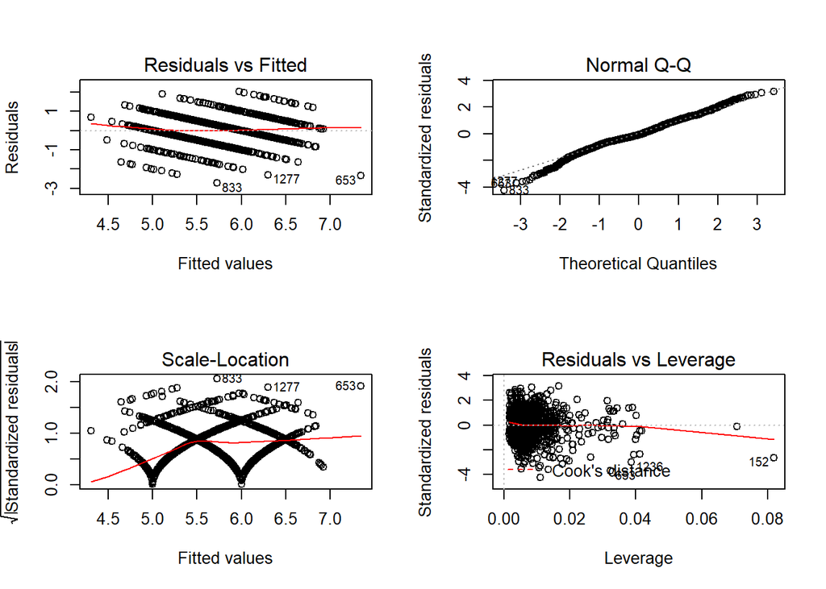

```r
oldpar=par(mfrow=c(2,2))
plot(lm_red_loggy_preds)
```

### Analysis

Short version:  
* the diagnostic plots pretty much look all the same between the models, so no reason to log transform

Longer version:  
* first of all, the plots for raw data “look good”, so no reason to try an alternate transform, e.g. `sqrt`, `log` (and in the interests of time…)  
* the residuals plots for all three look the same, mostly straight line through the data implies linearity in the predictors vs. outcome.  
* Q-Q, raw-data & log-predictors look the same, in a good way, meaning there appear to be normally distributed deviations. The log-all model shows a greater divergence from the diagonal line in the lower left compared to the other two, indicating a poorer fit.  
* Scale Location is pretty much identical for all models  
* the final plot, Residuals vs. Leverage, has good results for the raw data, even distribution of points, the red line is almost perfectly horizontal. The other two models show the same outlier(s) at the far right pulling the red line downwards. If we were to proceed with these versions we should consider, after due analysis, removing the one or two outliers at the far right.

As a sanity check, review the results of the `summary` on the red wine data set, and decide to output the `min/max` vaues for all the variables, both raw and log-transformed versions:

```r
rbind(apply(red, 2, min), apply(red, 2, max))
```

```
##      fixed_acidity volatile_acidity citric_acid residual_sugar chlorides
## [1,]           4.6             0.12           0            0.9     0.012
## [2,]          15.9             1.58           1           15.5     0.611
##      free_sulfur_dioxide total_sulfur_dioxide density   pH sulphates
## [1,]                   1                    6 0.99007 2.74      0.33
## [2,]                  72                  289 1.00369 4.01      2.00
##      alcohol y_quality
## [1,]     8.4         3
## [2,]    14.9         8
```

```r
rbind(apply(red_loggy_all, 2, min), apply(red_loggy_all, 2, max))
```

```
##      fixed_acidity volatile_acidity citric_acid residual_sugar  chlorides
## [1,]      1.722767        0.1133287   0.0000000      0.6418539 0.01192857
## [2,]      2.827314        0.9477894   0.6931472      2.8033604 0.47685510
##      free_sulfur_dioxide total_sulfur_dioxide   density       pH sulphates
## [1,]           0.6931472             1.945910 0.6881698 1.319086 0.2851789
## [2,]           4.2904594             5.669881 0.6949905 1.611436 1.0986123
##       alcohol y_quality
## [1,] 2.240710  1.386294
## [2,] 2.766319  2.197225
```

Basically, the range of values in the original data set don’t appear too extreme to begin with, e.g. there isn’t one variable with values from 1 to 10 and another 1 to 10,000. Comparing to the log-transformed versions reinforces the idea that there isn’t *too* much transformation going on.  
According to all three of the `lm` models, the most important variables are `volatile_acidity`, `chlorides`, `total_sulfur_dioxide`, `sulphates`, and `alcohol`. Which, `alcohol` aside, disagrees with my eyeball analysis of the boxplots I created based on “binned” quality. Either way, look at the range of values for three of the variables that my boxplots + my models both agree are influential (`volatile_acidity`, `sulphates`, `alcohol` and the range of those is especially small, i.e. the log-transormation doesn’t result in a large change in the values.

At this point my default for the `white` dataset will also be to stick with the original data, going to conduct some brief analysis below. (And I now realize I should have concentrated my more in-depth research on `white` instead of `red` as there are 3x the amount of data available and so any anylysis would have been more likely to be accurate.)  
In the interests of time, a quick `lm` on the original data + some diagnositic plots will hopefully confirm there is no reason to diverge from using untransformed variables.

### raw white data

```r
lm_white_raw = lm(y_quality~., white)
summary(lm_white_raw)
```

```
##
## Call:
## lm(formula = y_quality ~ ., data = white)
##
## Residuals:
##     Min      1Q  Median      3Q     Max
## -3.8348 -0.4934 -0.0379  0.4637  3.1143
##
## Coefficients:
##                          Estimate   Std. Error t value Pr(>|t|)
## (Intercept)           150.1928425   18.8041772   7.987 1.71e-15 ***
## fixed_acidity           0.0655200    0.0208737   3.139  0.00171 **
## volatile_acidity       -1.8631771    0.1137933 -16.373  < 2e-16 ***
## citric_acid             0.0220902    0.0957696   0.231  0.81759
## residual_sugar          0.0814828    0.0075273  10.825  < 2e-16 ***
## chlorides              -0.2472765    0.5465423  -0.452  0.65097
## free_sulfur_dioxide     0.0037328    0.0008441   4.422 9.99e-06 ***
## total_sulfur_dioxide   -0.0002857    0.0003781  -0.756  0.44979
## density              -150.2841806   19.0745080  -7.879 4.04e-15 ***
## pH                      0.6863437    0.1053791   6.513 8.10e-11 ***
## sulphates               0.6314765    0.1003856   6.291 3.44e-10 ***
## alcohol                 0.1934757    0.0242214   7.988 1.70e-15 ***
## ---
## Signif. codes:  0 '***' 0.001 '**' 0.01 '*' 0.05 '.' 0.1 ' ' 1
##
## Residual standard error: 0.7514 on 4886 degrees of freedom
## Multiple R-squared:  0.2819, Adjusted R-squared:  0.2803
## F-statistic: 174.3 on 11 and 4886 DF,  p-value: < 2.2e-16
```

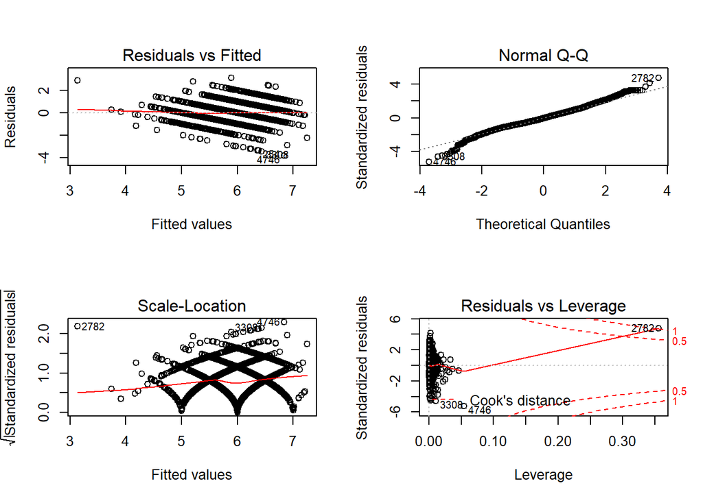

```r
oldpar=par(mfrow=c(2,2))
plot(lm_white_raw)
```

Everything looks good, except for the final Residuals vs. Leverage, which is a bit scary. Because of that, worth straying from “brief” review and instead dive a little deeper = look at the 2 log-transformed versions.

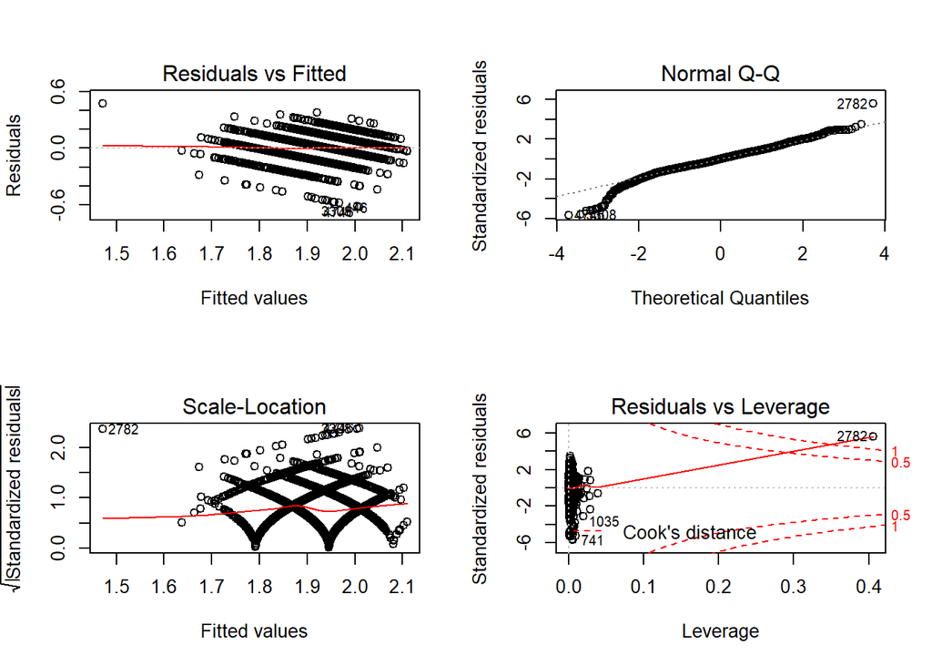

```r
# log transform all columns
white_loggy_all = log(white+1)
lm_white_loggy_all = lm(y_quality~., white_loggy_all)
oldpar=par(mfrow=c(2,2))
plot(lm_white_loggy_all)
```

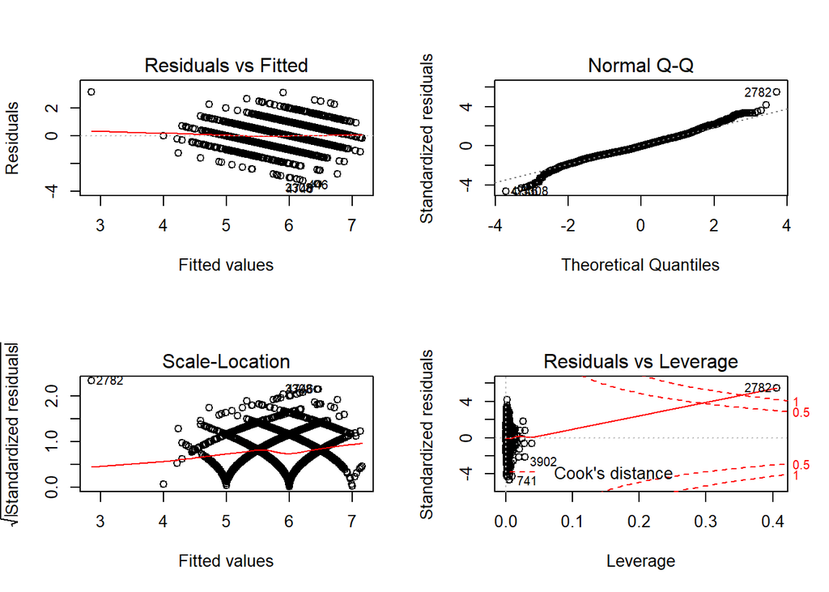

```r
# log transform all the predictor columns
white_loggy_pwhites = cbind(log(white[,-12]+1), white[,12])
colnames(white_loggy_pwhites) = wine_columns
lm_white_loggy_pwhites = lm(y_quality~., white_loggy_pwhites)
oldpar=par(mfrow=c(2,2))
plot(lm_white_loggy_pwhites)
```

Ok, good news in that these plots don’t show any obvious improvements, sticking with orig data for `white` as well.

Not sure if I’ll have time to fully evaluate but all three sets of plots indicate a potential problem with outlier(s). My intutition is that the data point on the upper-left of the Residuals vs. Fitted is the same one that throws off the Leverage chart, where it (or another data point) appears at the upper right. And that same point `2782` appears to an outlier on the Q-Q and Scale Location charts. The divergence of this point, from all other 4,897 observations, seems extreme enough that it would be safe to be considered an outlier and so eliminated.

### raw white data - outlier

```r
lm_white_raw_clean = lm(y_quality~., white[-2782,])
summary(lm_white_raw_clean)
```

```
##
## Call:
## lm(formula = y_quality ~ ., data = white[-2782, ])
##
## Residuals:
##     Min      1Q  Median      3Q     Max
## -3.8682 -0.4947 -0.0426  0.4610  3.1089
##
## Coefficients:
##                           Estimate    Std. Error t value Pr(>|t|)
## (Intercept)           211.42439858   22.73663156   9.299  < 2e-16 ***
## fixed_acidity           0.11080834    0.02289106   4.841 1.33e-06 ***
## volatile_acidity       -1.87540353    0.11357002 -16.513  < 2e-16 ***
## citric_acid             0.02523004    0.09555961   0.264    0.792
## residual_sugar          0.10142218    0.00859641  11.798  < 2e-16 ***
## chlorides              -0.07989962    0.54645945  -0.146    0.884
## free_sulfur_dioxide     0.00346227    0.00084419   4.101 4.18e-05 ***
## total_sulfur_dioxide    0.00002594    0.00038285   0.068    0.946
## density              -212.19363813   23.03954920  -9.210  < 2e-16 ***
## pH                      0.86928298    0.11192723   7.767 9.76e-15 ***
## sulphates               0.70155445    0.10123569   6.930 4.76e-12 ***
## alcohol                 0.11861343    0.02882011   4.116 3.92e-05 ***
## ---
## Signif. codes:  0 '***' 0.001 '**' 0.01 '*' 0.05 '.' 0.1 ' ' 1
##
## Residual standard error: 0.7497 on 4885 degrees of freedom
## Multiple R-squared:  0.2852, Adjusted R-squared:  0.2836
## F-statistic: 177.2 on 11 and 4885 DF,  p-value: < 2.2e-16
```

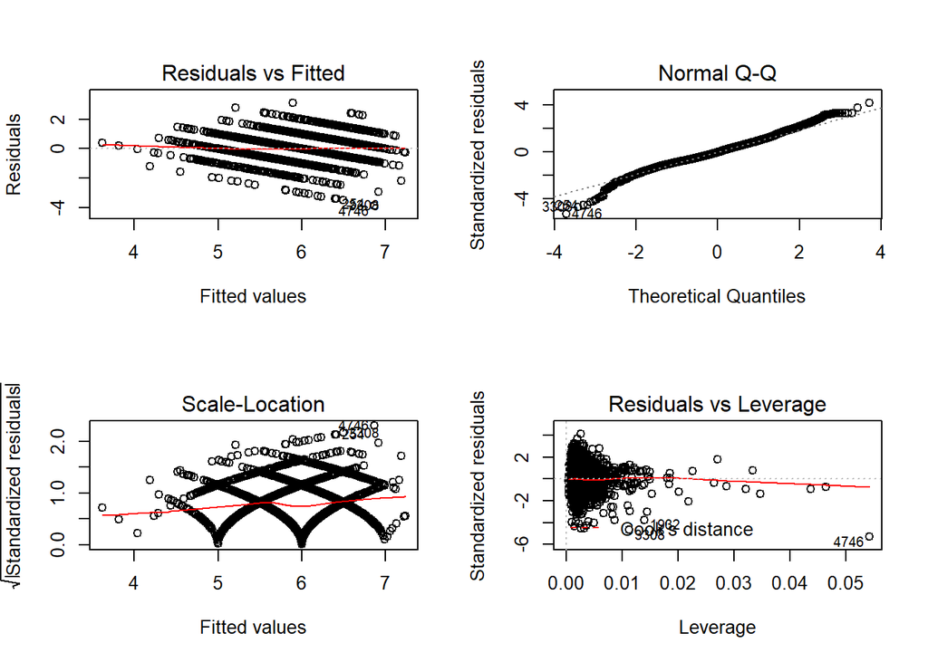

```r
oldpar=par(mfrow=c(2,2))
plot(lm_white_raw_clean)
```

Ah, much better. Going to indeed remove that outlier and create new model based on that cleaner `white` dataset. Also, re-create the `red` model with a new name based on the untransformed data, data is small enough that memory isn’t much of a concern. Also, do a `summary` on the `lm()` model for updated `white` dataset.

```r
lm_red = lm(y_quality~., red)
white = white[-2782,]
lm_white = lm(y_quality~., white)
summary(lm_white)
```

```
##
## Call:
## lm(formula = y_quality ~ ., data = white)
##
## Residuals:
##     Min      1Q  Median      3Q     Max
## -3.8682 -0.4947 -0.0426  0.4610  3.1089
##
## Coefficients:
##                           Estimate    Std. Error t value Pr(>|t|)
## (Intercept)           211.42439858   22.73663156   9.299  < 2e-16 ***
## fixed_acidity           0.11080834    0.02289106   4.841 1.33e-06 ***
## volatile_acidity       -1.87540353    0.11357002 -16.513  < 2e-16 ***
## citric_acid             0.02523004    0.09555961   0.264    0.792
## residual_sugar          0.10142218    0.00859641  11.798  < 2e-16 ***
## chlorides              -0.07989962    0.54645945  -0.146    0.884
## free_sulfur_dioxide     0.00346227    0.00084419   4.101 4.18e-05 ***
## total_sulfur_dioxide    0.00002594    0.00038285   0.068    0.946
## density              -212.19363813   23.03954920  -9.210  < 2e-16 ***
## pH                      0.86928298    0.11192723   7.767 9.76e-15 ***
## sulphates               0.70155445    0.10123569   6.930 4.76e-12 ***
## alcohol                 0.11861343    0.02882011   4.116 3.92e-05 ***
## ---
## Signif. codes:  0 '***' 0.001 '**' 0.01 '*' 0.05 '.' 0.1 ' ' 1
##
## Residual standard error: 0.7497 on 4885 degrees of freedom
## Multiple R-squared:  0.2852, Adjusted R-squared:  0.2836
## F-statistic: 177.2 on 11 and 4885 DF,  p-value: < 2.2e-16
```

> comment on correlation structure and whether some of the predictors suggest relationship with the outcome.

Produce a pair-wise plot of predictor variables to observe correlations among `red` predictors:

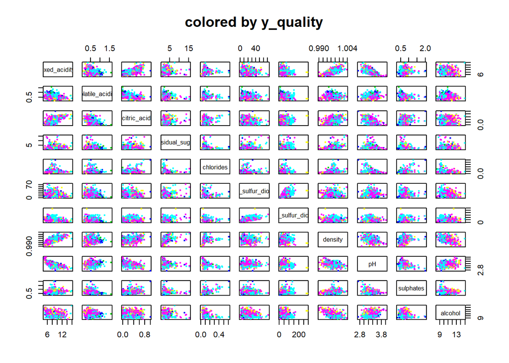

```r
#palette(rainbow(3, alpha = 0.5))
#pairs(data[2:8], pch=19, cex=0.4, col=(ceiling(data$y_rings/5)), main='colored by y_rings value, three bins')
pairs(red[1:11], pch=19, cex=0.4, col=red$y_quality, main='colored by y_quality')
```

As for correlation of predictors with outcome, run separate plots for outcome (`y_quality`) vs. predictors likely to have correlation with said outcome. For the `red` regression model, `volatile_acidity`, `chlorides`, `total_sulfur_dioxide`, `sulphates`, and `alcohol` had `***` indicating they were important. The `white` model included below, which only partially overalps with the same for `red`:  
* `fixed_acidity`, `volatile_acidity`, `residual_sugar`, `free_sulfur_dioxide`, `density`, `pH`, `sulphates`, `alcohol`

Create some simple plots of the overlapping variables, along with a simple linear regression against `y_quality` in order to draw a line: `volatile_acidity`, `sulphates`, `alcohol`

### red wines, plot select variables vs. outcome

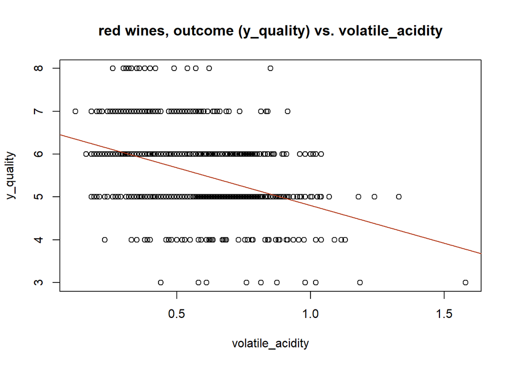

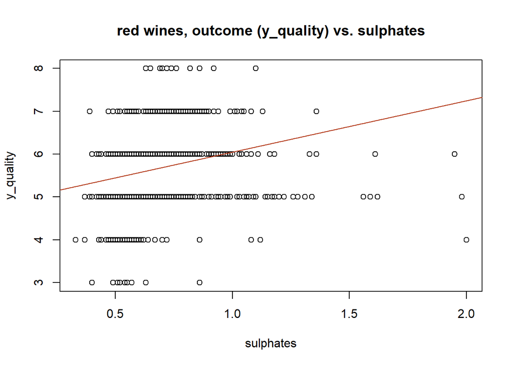

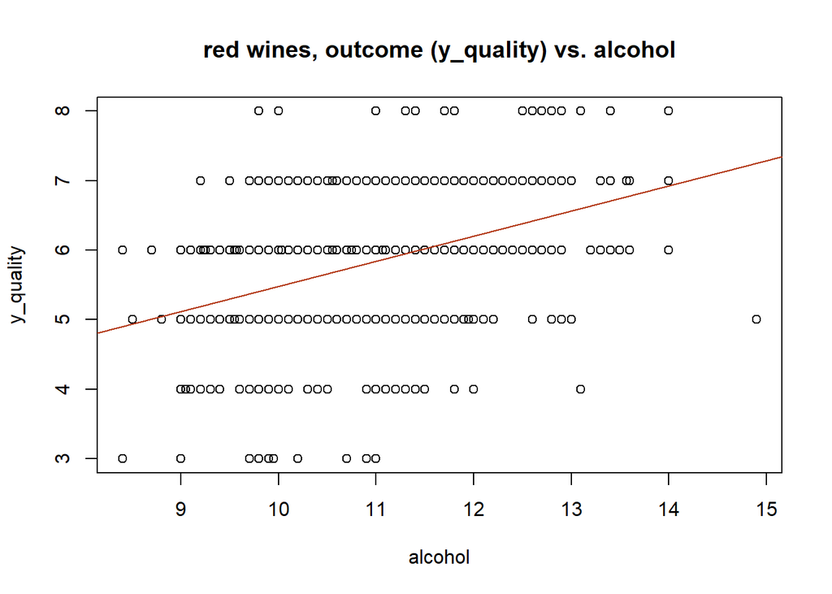

```r
some_vars = c('volatile_acidity',  'sulphates', 'alcohol')
#oldpar=par(mfrow=c(1,3))
for (one_var in some_vars){
  plot(red[,c(one_var,'y_quality')], main=paste0('red wines, outcome (y_quality) vs. ', one_var))
  abline(lm(y_quality~eval(as.symbol(one_var)), red), col=red_col)
}
```

The above plots support existence of relationships between each of the three selected variables and the outcome variable. The first, `volatile_acidity`, has a pronounced negative correlation with `y_quality` of red wine while both `sulphates` and `alcohol` show positive correlation, with higher values in each of those predictors leading to higher `y_quality` scores.

### white wines, plot select variables vs. outcome

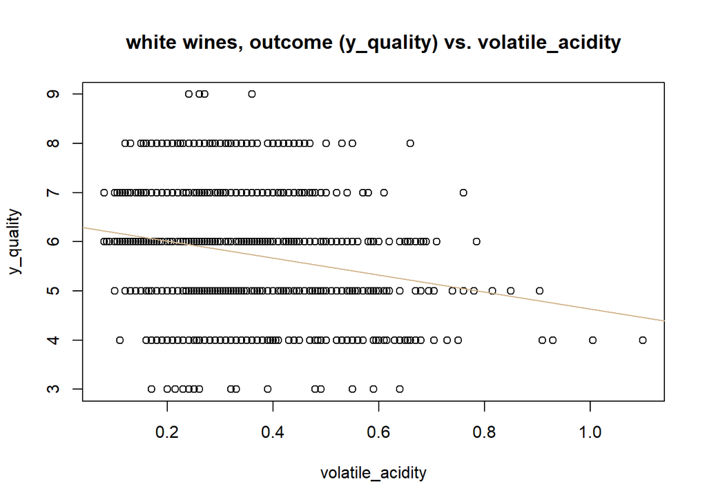

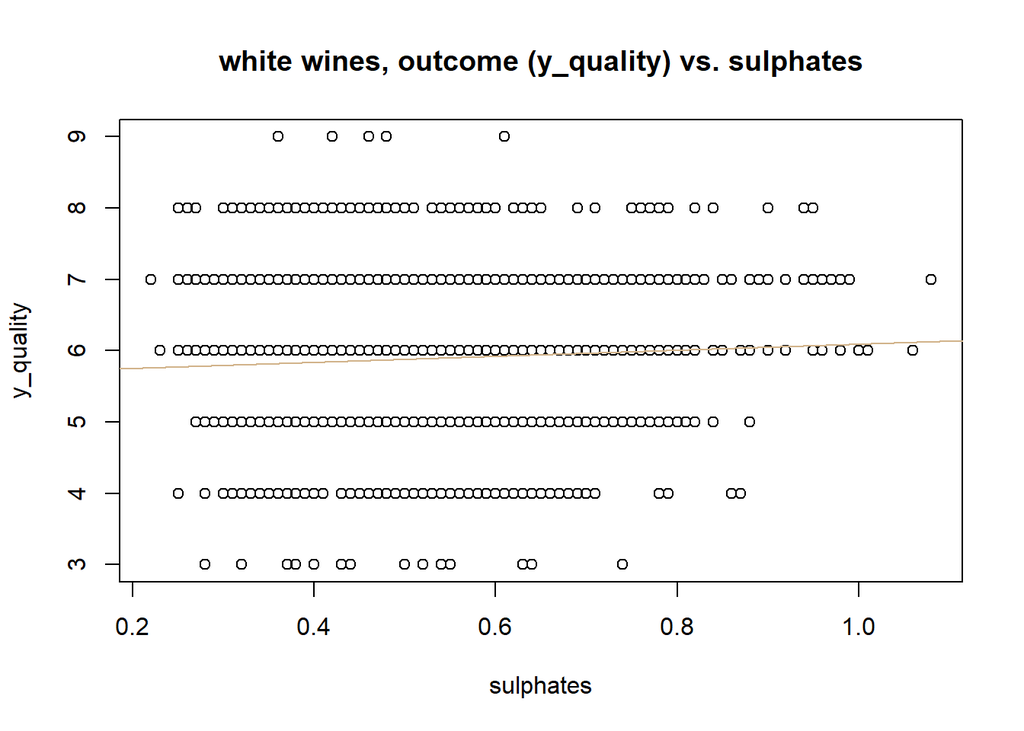

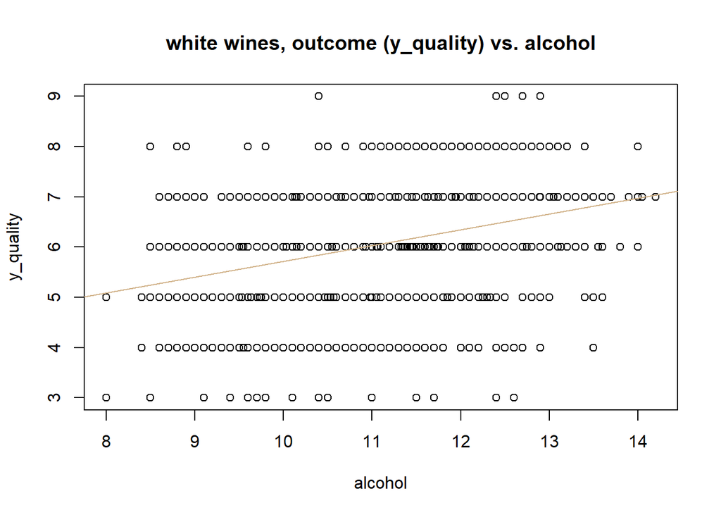

```r
for (one_var in some_vars){
  plot(white[,c(one_var,'y_quality')], main=paste0('white wines, outcome (y_quality) vs. ', one_var))
  abline(lm(y_quality~eval(as.symbol(one_var)), white), col='tan')
}
```

With the `white` wine plots we see the same relationships between `volatile_acidity` and `alcohol`, with the shallower `lm` lines indicating the relationships here are somewhat weaker than in the `red` dataset. The positive `sulphates` correlation is there also, but only slightly.

# Sub-problem 2: choose optimal models by exhaustive, forward and backward selection (20 points)

Use `regsubsets` from library `leaps` to choose optimal set of variables for modeling wine quality for red and white wine (separately), describe differences and similarities between attributes deemed important in each case.

> Use `regsubsets` from library `leaps` to choose optimal set of variables for modeling wine quality for red and white wine (separately) describe differences and similarities between attributes deemed important in each case

First, generate `regsubsets` related plots for `red` dataset, run subset selection through all available methods: exhaustive search, forward selection, backward selection, and sequential replacement.  
### NOTE: only noticed after most of my analysis that the problem does not include `sequential replacement` as one of the methods to test with. Going to leave in for now as its inclusion isn’t doing any harm, will update my text later, time permitting.

### red wine and regsubsets

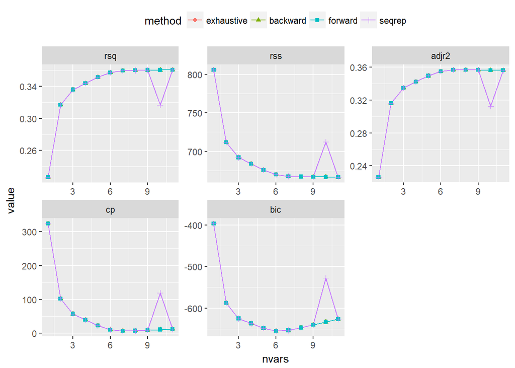

```r
summaryMetrics <- NULL
whichAll_red <- list()
my_methods = c('exhaustive', 'backward', 'forward', 'seqrep')
for ( myMthd in my_methods ) {
  method_metrics = NULL
  rsRes <- regsubsets(y_quality~., red, method=myMthd, nvmax=ncol(red)-1)
  summRes <- summary(rsRes)
  whichAll_red[[myMthd]] <- summRes$which
  for ( metricName in c('rsq','rss','adjr2','cp','bic') ) {
    summaryMetrics <- rbind(summaryMetrics,
      data.frame(method=myMthd,metric=metricName,
                nvars=1:length(summRes[[metricName]]),
                value=summRes[[metricName]]))
    method_metrics = rbind(method_metrics,
      data.frame(method=myMthd,metric=metricName,
                nvars=1:length(summRes[[metricName]]),
                value=summRes[[metricName]]))

  }
}
ggplot(summaryMetrics,aes(x=nvars,y=value,shape=method,colour=method)) + geom_path() + geom_point() + facet_wrap(~metric,scales='free') +   theme(legend.position='top')
```

Aside from some obvious aberrations from the `sequential replacement` approach at nvar=10, all four searches came up with similar results. Looking at the indvidual metrics, and the variable count at which gains level off, I would say `rsq`, `adr2`, `cp` all agree on nvar=7, `rss` either 7 or 8, and `bic` at 6. All things considered here I think 7 would be a reasonable variable count to go with.

### white wine and regsubsets

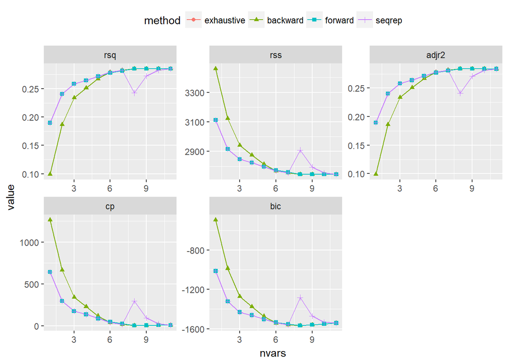

```r
summaryMetrics <- NULL
whichAll_white <- list()
my_methods = c('exhaustive', 'backward', 'forward', 'seqrep')
for ( myMthd in my_methods ) {
  method_metrics = NULL
  rsRes <- regsubsets(y_quality~., white, method=myMthd, nvmax=ncol(white)-1)
  summRes <- summary(rsRes)
  whichAll_white[[myMthd]] <- summRes$which
  for ( metricName in c('rsq','rss','adjr2','cp','bic') ) {
    summaryMetrics <- rbind(summaryMetrics,
      data.frame(method=myMthd,metric=metricName,
                nvars=1:length(summRes[[metricName]]),
                value=summRes[[metricName]]))
    method_metrics = rbind(method_metrics,
      data.frame(method=myMthd,metric=metricName,
                nvars=1:length(summRes[[metricName]]),
                value=summRes[[metricName]]))
  }
}
ggplot(summaryMetrics,aes(x=nvars,y=value,shape=method,colour=method)) + geom_path() + geom_point() + facet_wrap(~metric,scales='free') +   theme(legend.position='top')
```

Now we see some real disagreement in the search method results. `exhaustive` and `forward` are in agreement but at lower variable counts the metrics reported by `backward selection` are poorer, beginning to only match the other search methods once nvar gets to 6 or higher. As with the `red` wine, `sequential replacement` shows a short lived decrease in accuracy, this time at nvar=8, which gets better at nvar=9, before matching with other methods at nvar=10. Since the dataset was small enough that `exhaustive` subset could be performed, and its results agree with `forward`/`backward` at point before metric gains level off it I think it makes sense to more or less ignore `sequential replacement` results - that one shows dip at nvar=8, which is the variable count at which the other search methods report best results.

At this point the results would recommend a `red` wine model with 7 variables vs. 8 for `white` wine dataset.  
Next will be examining the actual variables selected by the search methods at each nvar count.

### variable selection, red

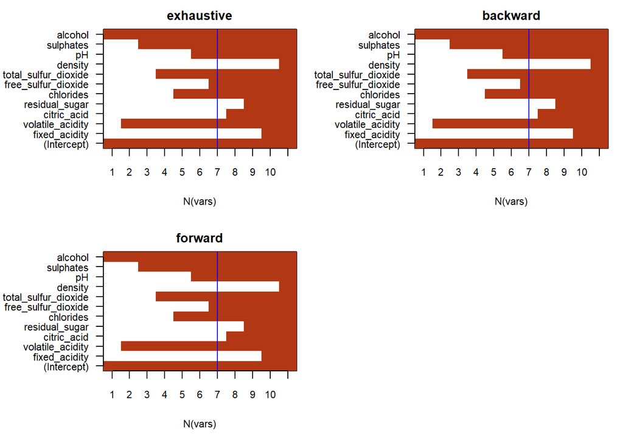

```r
#TODO: 2x1 charts to make bigger?
# at this point realize we don't need/want the seqrep results, skip it in the results
old.par <- par(mfrow=c(2,2),ps=10,mar=c(5,7,2,1))
for ( myMthd in names(whichAll_red[-length(whichAll_red)]) ) {
  image(1:nrow(whichAll_red[[myMthd]]),
        1:ncol(whichAll_red[[myMthd]]),
        whichAll_red[[myMthd]],xlab='N(vars)',ylab='',
        xaxt='n',yaxt='n',breaks=c(-0.5,0.5,1.5),
        col=c('white',red_col),main=myMthd)
  axis(1,1:nrow(whichAll_red[[myMthd]]),rownames(whichAll_red[[myMthd]]))
  axis(2,1:ncol(whichAll_red[[myMthd]]),colnames(whichAll_red[[myMthd]]),las=2)
  abline(v=7, col='blue')
}
```

Nice to see that there appears to be full agreement at each variable count as to which variables to include. More specifically the blue line at nvar=7 indicates agreement at the nvar selected by earlier search methods on `red` dataset.

### variable selection, white

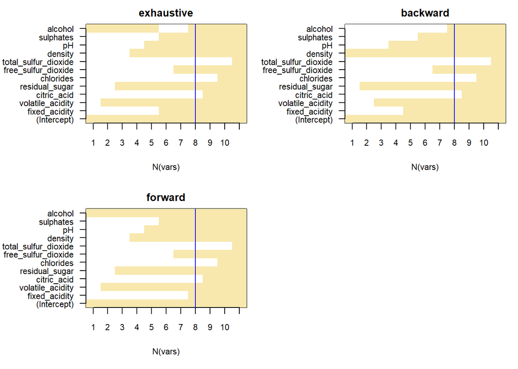

```r
old.par <- par(mfrow=c(2,2),ps=10,mar=c(5,7,2,1))
for ( myMthd in names(whichAll_white[-length(whichAll_white)]) ) {
  image(1:nrow(whichAll_white[[myMthd]]),
        1:ncol(whichAll_white[[myMthd]]),
        whichAll_white[[myMthd]],xlab='N(vars)',ylab='',
        xaxt='n',yaxt='n',breaks=c(-0.5,0.5,1.5),
        col=c('white',white_col),main=myMthd)
  axis(1,1:nrow(whichAll_white[[myMthd]]),rownames(whichAll_white[[myMthd]]))
  axis(2,1:ncol(whichAll_white[[myMthd]]),colnames(whichAll_white[[myMthd]]),las=2)
    abline(v=8, col='blue')
}
```

Now the best-nvar blue line is at 8 and we can see the specific variables selected at that variable count is the same set throughout each search pattern. Looking at earlier variable counts there are definitely some differences, e.g. `alcohol` goes in and out in `exhaustive` and doesn’t come into play in `backward` selection until n=8.

# Sub-problem 3: optimal model by cross-validation (25 points)

Use cross-validation (or any other resampling strategy of your choice) to estimate test error for models with different numbers of variables. Compare and comment on the number of variables deemed optimal by resampling versus those selected by `regsubsets` in the previous task. Compare resulting models built separately for red and white wine data.

> Use cross-validation (or any other resampling strategy of your choice) to estimate test error for models with different numbers of variables.

Create a function for use with both wine datasets

```r
# update function from week 5 solutions to handle either red or white (y_quality is hard-coded within)
xvalMSEregsubsetsWine <- function(data, nTries=30, kXval=5) {
  retRes <- NULL
  for ( iTry in 1:nTries ) {
    xvalFolds <- sample(rep(1:kXval, length.out=nrow(data)))
    # Try each method available in regsubsets
    # to select the best model of each size, skip 'seqrep' to match with earlier resuls
    for ( jSelect in c("exhaustive", "backward", "forward") ) {
      mthdTestErr2 <- NULL
      mthdTrainErr2 <- NULL
      mthdTestFoldErr2 <- NULL
      for ( kFold in 1:kXval ) {
        rsTrain <- regsubsets(y_quality~., data[xvalFolds!=kFold,], nvmax=ncol(data)-1, method=jSelect)
        # Calculate test error for each set of variables using predict.regsubsets implemented above:
        nVarTestErr2 <- NULL
        nVarTrainErr2 <- NULL
        for ( kVarSet in 1:(ncol(data)-1) ) {
          # make predictions for given number of variables and cross-validation fold:
          kCoef <- coef(rsTrain,id=kVarSet)
          testPred <- model.matrix(y_quality~.,data[xvalFolds==kFold,])[,names(kCoef)] %*% kCoef
          nVarTestErr2 <- cbind(nVarTestErr2,(testPred-data[xvalFolds==kFold,"y_quality"])^2)
          trainPred <- model.matrix(y_quality~.,data[xvalFolds!=kFold,])[,names(kCoef)] %*% kCoef
          nVarTrainErr2 <- cbind(nVarTrainErr2,(trainPred-data[xvalFolds!=kFold,"y_quality"])^2)
        }
        # accumulate training and test errors over all cross-validation folds:
        mthdTestErr2 <- rbind(mthdTestErr2,nVarTestErr2)
        mthdTestFoldErr2 <- rbind(mthdTestFoldErr2,colMeans(nVarTestErr2))
        mthdTrainErr2 <- rbind(mthdTrainErr2,nVarTrainErr2)
      }
      # add to data.frame for future plotting:
      retRes <- rbind(retRes,
                data.frame(sim=iTry,sel=jSelect,vars=1:ncol(nVarTrainErr2),mse=colMeans(mthdTrainErr2),trainTest="train"),
                data.frame(sim=iTry,sel=jSelect,vars=1:ncol(nVarTrainErr2),mse=colMeans(mthdTestErr2),trainTest="test"))
    }
  }
  retRes
}
#df2 = data.frame(xvalMSEregsubsetsWine(data=red, 10 ,kXval=2), xval="2-fold")
#df2a = df2[which(df2$vars!=1),]
#ggplot(df2a, aes(x=factor(vars),y=mse,colour=sel)) + geom_boxplot()+facet_wrap(~trainTest+xval)
```

### 5-fold, 10-fold cross validation on red dataset

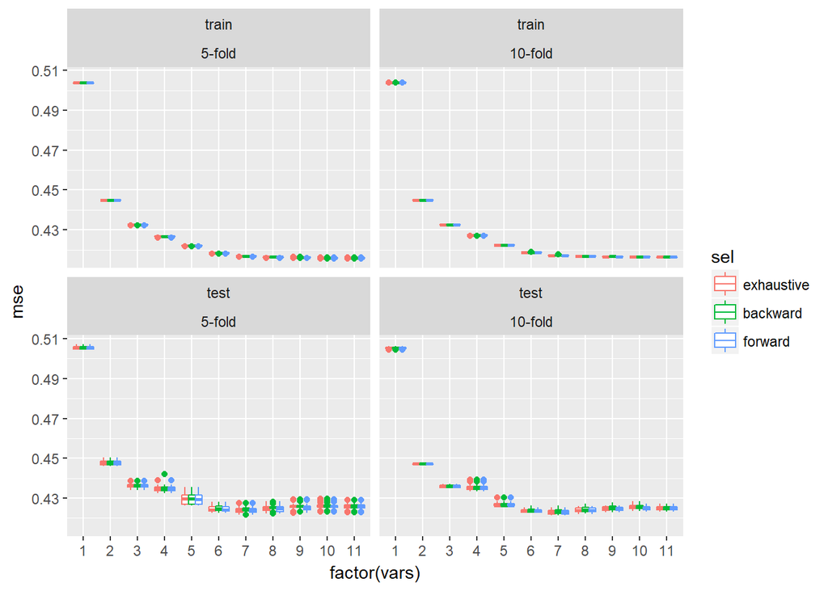

```r
# plot MSEs by training/test, number of variables, reduce nTries to 20 in interest of expediency, and only 5/10 folds
dfTmpRed <- rbind(data.frame(xvalMSEregsubsetsWine(data=red, nTries=20, kXval=5), xval="5-fold"),
              data.frame(xvalMSEregsubsetsWine(data= red, nTries=20, kXval=10), xval="10-fold"))
ggplot(dfTmpRed,aes(x=factor(vars),y=mse,colour=sel)) + geom_boxplot()+facet_wrap(~trainTest+xval)
```

```r
# for viz testing, runs quickly:
#ggplot(data.frame(xvalMSEregsubsetsWine(data=red, 10 ,kXval=2), xval="2-fold"),
#       aes(x=factor(vars),y=mse,colour=sel)) + geom_boxplot()+facet_wrap(~trainTest+xval)
```

Cross-validation is probably the only time so far I’ve run into significant calculation durations, though all things considered it isn’t too much. Even so I’ve already reduced `nTries` to 20 and skipped the 2-fold validation used in other examples.

Now for cross-validation on the `white` dataset.